# Fletcher and Fortin, Chapter 6

Varied Thrush Example Walkthrough

## 0.1 Authors’ correlogram function

Note that there is a mistake in the definition of the `moran.results` data frame.

They define two columns called `null.lower`, however one of them should have been `null.upper`

```r
icorrelogram <- function(locations, z, binsize, maxdist)
{
  # package 'spdep' needed for dnearneigh() function.
  # Check whether it is installed:
  stopifnot(require(spdep))

  distbin <- seq(0, maxdist, by = binsize)
  Nbin <- length(distbin)-1

  moran.results <- data.frame(
    "dist" =  rep(NA, Nbin),
    "Morans.i" = NA,
    "null.lower" = NA,
    "null.upper" = NA)

  for (i in 1:Nbin){
    d.start <- distbin[i]
    d.end <- distbin[i+1]

    neigh <- spdep::dnearneigh(
      x = locations,
      d1 = d.start,
      d.end,
      longlat = F)

    wts <- nb2listw(
      neighbours = neigh,
      style = 'B',
      zero.policy = T)

    #note alternative is for P-value, so only 'significant if positive autocorrelation
    mor.i <- moran.mc(
      x = z, listw = wts,
      nsim = 200,
      alternative = "greater",
      zero.policy = T)

    moran.results[i, "dist"] <- (d.end+d.start)/2

    #observed moran's i
    moran.results[i, "Morans.i"] <- mor.i$statistic

    moran.results[i, "null.lower"] <-
      quantile(
        mor.i$res,
        probs = 0.025,
        na.rm = T)#95% null envelope

    moran.results[i, "null.upper"] <-
      quantile(
        mor.i$res,
        probs = 0.975,
        na.rm = T)#95% null envelope
  }
  return(moran.results)
}

# plotting function
#
plot_ff_correlogram = function(cgram, title, subttl = "", thm = theme_light(), ci_lty = 2)
{
  require(ggplot2)
  return(
    ggplot(cgram, aes(x = dist)) +
      geom_line(aes(y = Morans.i)) +
      geom_line(aes(y = null.upper), lty = ci_lty) +
      geom_line(aes(y = null.lower), lty = ci_lty) +
      ylab("Moran's I") + xlab("distance") +
      ggtitle(title, subttl) +
      geom_hline(yintercept = 0, lty = 3)
  )
}
```

# 1 Data import

## 1.1 Elevation data

Northern Idaho, western Montana.

```r
# elev = raster(file.path(book_data, "elev.gri"))
# elev = raster(file.path(book_data, "elev.grd"))
elev = raster(file.path(book_data, "elev"))
```

Compute slope and aspect using `raster` package.

NOTE: The second line of code in the example provided in the text fails:

```r
elev.terr <- terrain( elev, opt = c(" slope", "aspect"), unit = "radians")
```

```
## Error in .local(x, ...): !is.na(projection(x)) is not TRUE
```

They neglect to mention that the raster they provide does not include projection information:

```r
proj4string(elev)=CRS(" +proj=aea +lat_1=46 +lat_2=48 +lat_0=44 +lon_0=-109.5 +x_0=600000 +y_0=0 +ellps=GRS80 +datum=NAD83 +units=m +no_defs")
```

Build terrain layers using `terrain()` in the `raster` package

Note: the book code specifies the unit as radians, the supplemental material code does not:

```r
# Supplemental code version
# elev.terr <- terrain(elev, opt = c("slope", "aspect"))

# Book version
elev.terr <- terrain(elev, opt = c("slope", "aspect"), unit = "radians")
```

Create a raster stack to hold all the layers:

```r
layers <- stack(elev, elev.terr)
layers <- brick(elev, elev.terr)
names(layers) <- c("elev", "slope", "aspect")
class(layers)
```

```
## [1] "RasterBrick"
## attr(,"package")
## [1] "raster"
```

You can use `subset()` to select a particular layer i n a `RasterStack` or `RasterBrick` object.

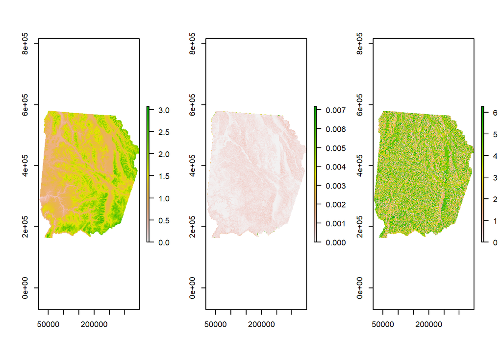

```r
par(mfrow = c(1, 3))
plot(subset(layers, 1))
plot(subset(layers, 2))
plot(subset(layers, 3))
```

## 1.2 Varied Thrush Data

Import and plot:

```r
#Point data with presence/absence
point.data <- read.csv(file.path(book_data, "vath_2004.csv"), header = TRUE)

dev.off()
```

```r
plot(subset(layers, 1))

#plots the presence points
points(point.data[point.data$VATH == 0, c("EASTING", "NORTHING")], col = "black", pch = 21, cex = 0.8)

#plots the absence points
points(point.data[point.data$VATH == 1, c("EASTING", "NORTHING")], col = "red", pch = 16, cex = 0.7)
```

[output not shown]

Extract data data at sampling points

```r
coords <- cbind(point.data$EASTING, point.data$NORTHING)
land.cov <- extract(x = layers, y = coords)
point.data <- cbind(point.data, land.cov)
```

# 2 Aspatial logistic regression

## 2.1 Data set-up

### 2.1.1 Check for collinearity (correlations among predictors)

```r
cor(point.data[, c("elev", "slope", "aspect")], method = "pearson")
```

```
##               elev      slope      aspect
## elev    1.00000000 0.15910701 -0.08920279
## slope   0.15910701 1.00000000  0.03533303
## aspect -0.08920279 0.03533303  1.00000000
```

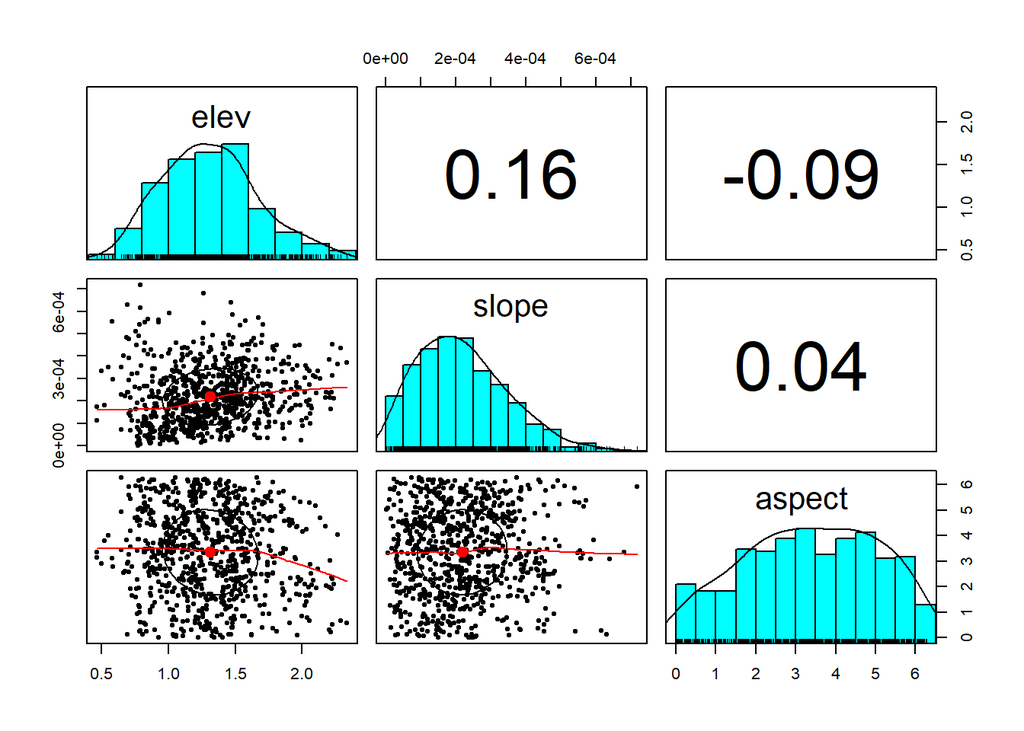

```r
# pairs(point.data[, c("elev", "slope", "aspect")])
# the psych package implementatin looks much nicer
psych::pairs.panels(point.data[, c("elev", "slope", "aspect")])
```

### 2.1.2 Center and scale predictors for modeling

```r
point.data$elevs <- scale(point.data$elev, center = T, scale = T)
point.data$slopes <- scale(point.data$slope, center = T, scale = T)
point.data$aspects <- scale(point.data$aspect, center = T, scale = T)
```

## 2.2 Model 1: elevation

```r
VATH.elev <- glm(
  VATH ~ elev,
  family = "binomial",
  data = point.data)
summary(VATH.elev)
```

```
##
## Call:
## glm(formula = VATH ~ elev, family = "binomial", data = point.data)
##
## Deviance Residuals:
##     Min       1Q   Median       3Q      Max
## -0.6571  -0.5324  -0.4821  -0.4314   2.2940
##
## Coefficients:
##             Estimate Std. Error z value Pr(>|z|)
## (Intercept)  -1.0889     0.4140   -2.63  0.00853 **
## elev         -0.7219     0.3208   -2.25  0.02444 *
## ---
## Signif. codes:  0 '***' 0.001 '**' 0.01 '*' 0.05 '.' 0.1 ' ' 1
##
## (Dispersion parameter for binomial family taken to be 1)
##
##     Null deviance: 584.34  on 804  degrees of freedom
## Residual deviance: 579.10  on 803  degrees of freedom
## AIC: 583.1
##
## Number of Fisher Scoring iterations: 5
```

## 2.3 Model 2: additive - all factors

```r
VATH.all <- glm(
  VATH ~ elevs + slopes + aspects,
  family = "binomial",
  data = point.data)
summary(VATH.all)
```

```
##
## Call:
## glm(formula = VATH ~ elevs + slopes + aspects, family = "binomial",
##     data = point.data)
##
## Deviance Residuals:
##     Min       1Q   Median       3Q      Max
## -0.6847  -0.5399  -0.4754  -0.4199   2.3525
##
## Coefficients:
##             Estimate Std. Error z value Pr(>|z|)
## (Intercept) -2.04628    0.11269 -18.158   <2e-16 ***
## elevs       -0.25493    0.11606  -2.197    0.028 *
## slopes      -0.08421    0.11172  -0.754    0.451
## aspects     -0.13852    0.10973  -1.262    0.207
## ---
## Signif. codes:  0 '***' 0.001 '**' 0.01 '*' 0.05 '.' 0.1 ' ' 1
##
## (Dispersion parameter for binomial family taken to be 1)
##
##     Null deviance: 584.34  on 804  degrees of freedom
## Residual deviance: 576.83  on 801  degrees of freedom
## AIC: 584.83
##
## Number of Fisher Scoring iterations: 5
```

## 2.4 Model 3: polynomial elevation

```r
VATH.elev2 <- glm(
  VATH ~ elev + I(elev^2),
  family = "binomial",
  data = point.data)
summary(VATH.elev2)
```

```
##
## Call:
## glm(formula = VATH ~ elev + I(elev^2), family = "binomial", data = point.data)
##
## Deviance Residuals:
##     Min       1Q   Median       3Q      Max
## -0.6088  -0.5787  -0.5032  -0.3231   3.0804
##
## Coefficients:
##             Estimate Std. Error z value Pr(>|z|)
## (Intercept)   -7.984      1.990  -4.012 6.01e-05 ***
## elev          10.698      3.227   3.316 0.000915 ***
## I(elev^2)     -4.476      1.281  -3.494 0.000475 ***
## ---
## Signif. codes:  0 '***' 0.001 '**' 0.01 '*' 0.05 '.' 0.1 ' ' 1
##
## (Dispersion parameter for binomial family taken to be 1)
##
##     Null deviance: 584.34  on 804  degrees of freedom
## Residual deviance: 560.54  on 802  degrees of freedom
## AIC: 566.54
##
## Number of Fisher Scoring iterations: 6
```

## 2.5 Model Selection

The polynomial elevation model has lowest AIC

```r
AIC(VATH.elev, VATH.all, VATH.elev2)
```

```
##            df      AIC
## VATH.elev   2 583.1021
## VATH.all    4 584.8349
## VATH.elev2  3 566.5389
```

Extract coefficients and their SEs from the best model

```r
summary(VATH.elev2)$coef
```

```
##              Estimate Std. Error   z value     Pr(>|z|)
## (Intercept) -7.983676   1.989748 -4.012406 6.010296e-05
## elev        10.698244   3.226676  3.315562 9.145911e-04
## I(elev^2)   -4.476405   1.281045 -3.494340 4.752357e-04
```

```r
glm.summary <- c(
  summary(VATH.elev2)$coef[2, 1],
  summary(VATH.elev2)$coef[2, 2],
  summary(VATH.elev2)$coef[3, 1],
  summary(VATH.elev2)$coef[3, 2])
#inspect
glm.summary
```

```
## [1] 10.698244  3.226676 -4.476405  1.281045
```

# 3 Plot (aspatial) model

## 3.1 Use model to plot predicted Pr(abundance)

First create a new (aspatial) data set to use with `predict()`

```r
Elev <-  seq(
  min(point.data$elev),
  max(point.data$elev),
  length = 15)
newdata <- data.frame(elev = Elev)
```

Use model to predict values for different elevations:

```r
# type = response for predicted probabilities
glm.pred <- predict(
  VATH.elev2,
  newdata = newdata,
  type =  "link",
  se = T)
```

Logistic regression fits are given in quantiles of the **logistic distribution**, but these numbers aren’t very intuitive to interpret. We can back-transform them onto a probability scale:

```r
glm.newdata <-
  data.frame(
    newdata,
    pred = plogis(glm.pred$fit),
    lcl = plogis(glm.pred$fit + 1.96*glm.pred$se.fit),
    ucl = plogis(glm.pred$fit - 1.96*glm.pred$se.fit))
```

## 3.2 Plot model coeff. with confidence intervals

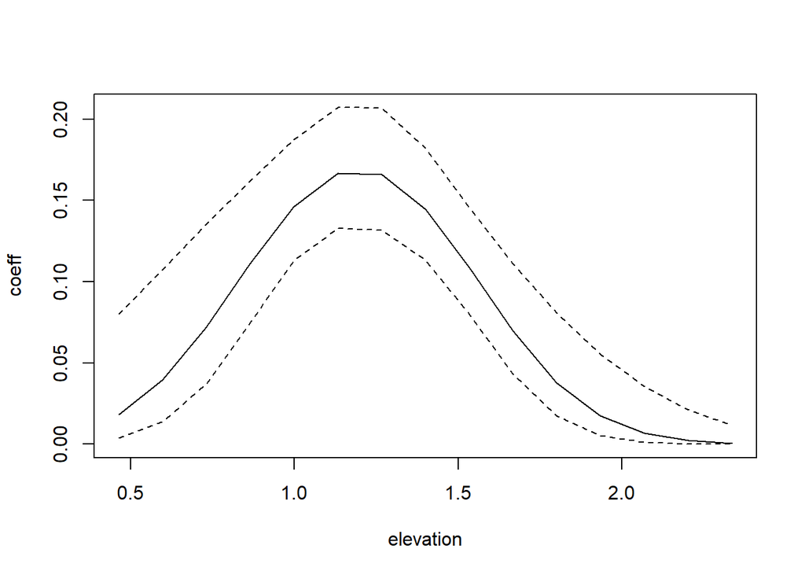

```r
with(
  glm.newdata,
  matplot(
    x = elev, y = cbind(pred, lcl, ucl),
    type = "l", col = 1, lty = c(1, 2, 2),
    xlab = "elevation", ylab = "coeff"),
  ylim = c(0, 0.3)
)
```

## 3.3 Map of model predictions

The `raster` package includes an implementation of `predict` that we can use to create a raster layer of model predictions:

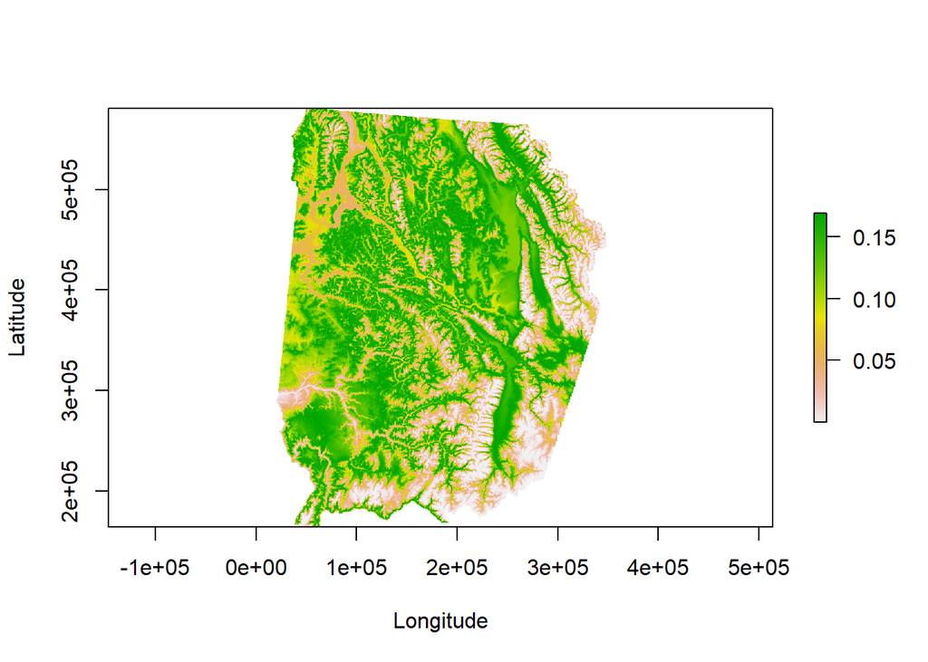

```r
glm.raster <- predict(
  model = VATH.elev2,
  object = layers,
  type = "response")
plot(glm.raster, xlab = "Longitude", ylab = "Latitude")
```

# 4 Spatial dependence of model output

## 4.1 Correlogram of response

Create a correlogram using the authors’ function:

```r
VATH.cor <- icorrelogram(
  locations = coords,
  z = point.data$VATH,
  binsize = 1000,
  maxdist = 15000)
```

[output not shown]

```r
VATH.cor
```

```
##     dist     Morans.i  null.lower null.upper
## 1    500  0.343961125 -0.05264640 0.05166277
## 2   1500  0.101882576 -0.03652262 0.03772909
## 3   2500  0.005437021 -0.01438219 0.02114825
## 4   3500  0.008807170 -0.01371664 0.02225493
## 5   4500  0.003784033 -0.01723364 0.02616134
## 6   5500  0.038709975 -0.01936443 0.02715590
## 7   6500  0.001599187 -0.01718016 0.02224579
## 8   7500  0.007590704 -0.01241127 0.02129468
## 9   8500  0.004376028 -0.01881872 0.02576674
## 10  9500  0.043655309 -0.02544273 0.03240467
## 11 10500  0.022623901 -0.02592198 0.01997511
## 12 11500 -0.005603860 -0.02650823 0.02699566
## 13 12500  0.073450494 -0.02565459 0.02431331
## 14 13500  0.018757123 -0.02366030 0.03463139
## 15 14500  0.023673746 -0.02509961 0.02658728
```

NOTE: the authors had an error in the `lines()` call below. They misspecified the upper and lower null envelope column names in the original.

```r
round(head(VATH.cor, 3), 2)
```

```
##   dist Morans.i null.lower null.upper
## 1  500     0.34      -0.05       0.05
## 2 1500     0.10      -0.04       0.04
## 3 2500     0.01      -0.01       0.02
```

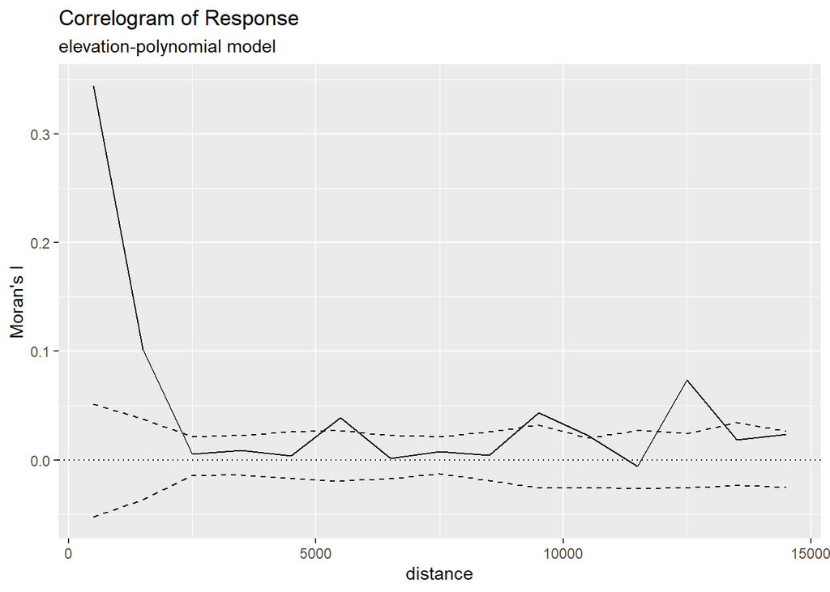

```r
plot_ff_correlogram(VATH.cor, "Correlogram of Response", "elevation-polynomial model")
```

## 4.2 Correlogram of model residuals

Build a correlogram with the authors’ function:

```r
VATH.elev2.res <- residuals(VATH.elev2, type = "deviance")
corr.res <- icorrelogram(
  locations = coords,
  z = VATH.elev2.res,
  binsize = 1000,
  maxdist = 15000)
```

NOTE: same comment as above about error in column names.

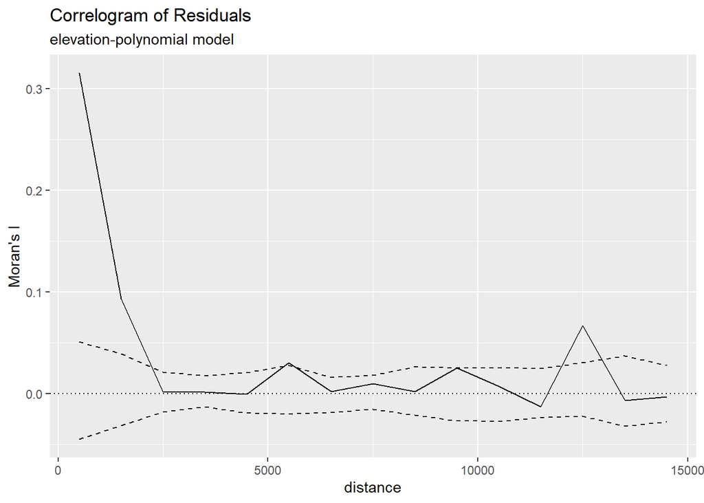

```r
plot_ff_correlogram(corr.res, "Correlogram of Residuals", "elevation-polynomial model")
```

contrast results from raw to residuals with mean correlogram on residuals of mean model (intercept model)

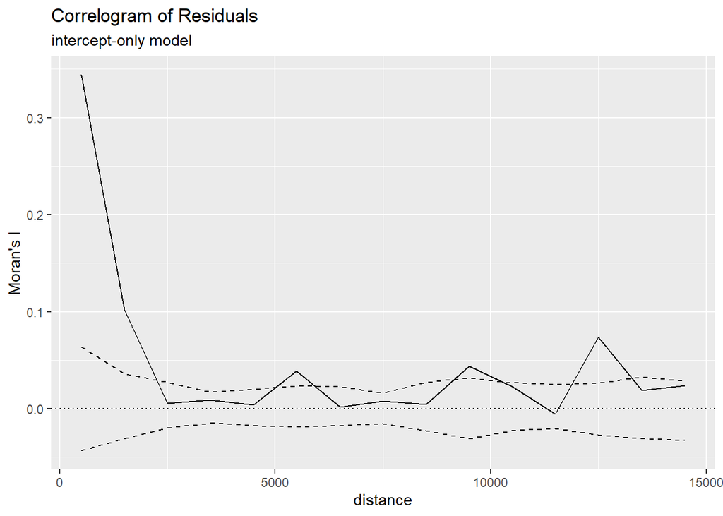

```r
VATH.int <- glm(VATH ~ 1, family = "binomial", data = point.data)
VATH.int.res <- residuals(VATH.int, type = "deviance")
corr.int.res <- icorrelogram(locations = coords, z = VATH.int.res, binsize = 1000, maxdist = 15000)

plot_ff_correlogram(corr.int.res, "Correlogram of Residuals", "intercept-only model")
```

correlation

```r
cor(VATH.cor$Morans.i, corr.int.res$Morans.i)
```

```
## [1] 1
```

# 5 Subset data to account for autocorrelation —-

```r
#randomly shuffle data by transect and create a shuffled rank vector
rand.vector <- with(
  point.data,
  ave(
    POINT,
    as.factor(TRANSECT),
    FUN = function(x) {sample(length(x))}))

#pick one random point on transect and remove rest
point.datasub <- point.data[rand.vector  <=  1, ]
head(point.datasub, 3)
```

```
##    SURVEYID  TRANSECT POINT VATH  EASTING NORTHING  elev        slope   aspect
## 4         4 452511619     9    0 58754.24 172876.0 1.140 0.0004042006 1.449894
## 5         5 452511625     1    0 59037.42 181450.2 1.174 0.0001162163 5.954632
## 11       11 452711607     3    0 81967.28 184088.0 1.857 0.0001725838 3.334727
##         elevs     slopes    aspects
## 4  -0.4823973  1.4559846 -1.1443703
## 5  -0.3871077 -0.7974223  1.5585550
## 11  1.5270893 -0.3563605 -0.0134358
```

coordinates subset

```r
coords.sub <- cbind(point.datasub$NORTHING, point.datasub$NORTHING)
head(coords.sub, 3)
```

```
##          [,1]     [,2]
## [1,] 172876.0 172876.0
## [2,] 181450.2 181450.2
## [3,] 184088.0 184088.0
```

```r
#model
VATH.sub <- glm(VATH~elev + I(elev^2), family = "binomial", data = point.datasub)
summary(VATH.sub)
```

```
##
## Call:
## glm(formula = VATH ~ elev + I(elev^2), family = "binomial", data = point.datasub)
##
## Deviance Residuals:
##     Min       1Q   Median       3Q      Max
## -0.6497  -0.6249  -0.5425  -0.3539   2.6574
##
## Coefficients:
##             Estimate Std. Error z value Pr(>|z|)
## (Intercept)   -9.520      4.461  -2.134   0.0328 *
## elev          11.945      6.800   1.757   0.0790 .
## I(elev^2)     -4.419      2.544  -1.737   0.0823 .
## ---
## Signif. codes:  0 '***' 0.001 '**' 0.01 '*' 0.05 '.' 0.1 ' ' 1
##
## (Dispersion parameter for binomial family taken to be 1)
##
##     Null deviance: 133.87  on 166  degrees of freedom
## Residual deviance: 129.53  on 164  degrees of freedom
## AIC: 135.53
##
## Number of Fisher Scoring iterations: 5
```

extract coefficients

```r
glmsub.summary <-
  c(
    summary(VATH.sub)$coef[2, 1],
    summary(VATH.sub)$coef[2, 2],
    summary(VATH.sub)$coef[3, 1],
    summary(VATH.sub)$coef[3, 2])
```

residuals #correlogram on residuals

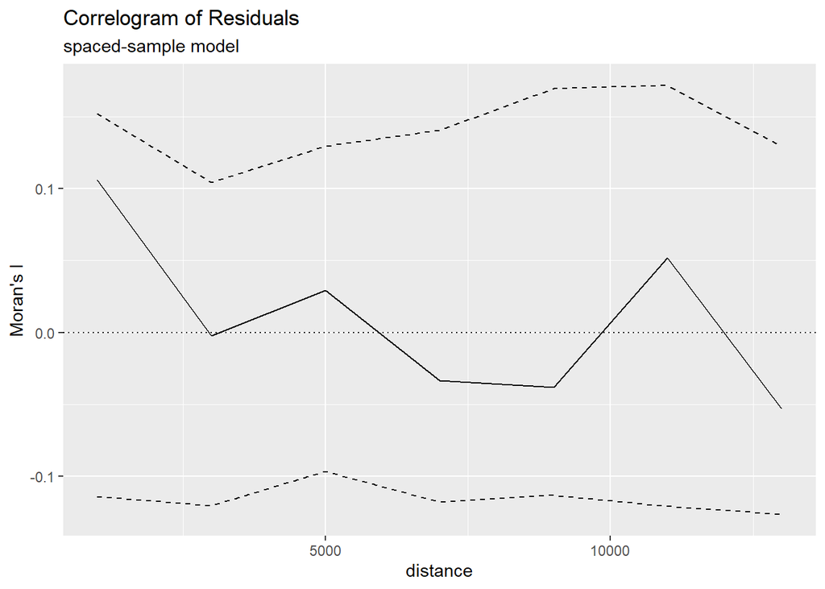

```r
VATH.sub.res <- residuals(VATH.sub, type = "deviance")
corr.sub.res <- icorrelogram(locations = coords.sub, z = VATH.sub.res, binsize = 2000, maxdist = 15000)
plot_ff_correlogram(corr.sub.res, "Correlogram of Residuals", "spaced-sample model")
```